# PRÁCTICA 5A: CLASIFICACIÓN DE TEXTO

PROFESOR: DR. LUIS GUILLERMO RUIZ VELÁZQUEZ

ESTUDIANTE: EDGAR SANTIAGO GONZALEZ MARTINEZ

# Introducción

En esta práctica se aborda el problema de clasificación automática de texto, enfocándose en la predicción de la emoción asociada a tweets a partir de un conjunto de datos etiquetado con distintos emojis. A partir de los archivos `emojis_train.csv` y `emojis_test.csv`, el objetivo principal es construir y evaluar modelos de aprendizaje automático capaces de asignar correctamente una de las categorías emocionales, por ejemplo Corazón (❤), cara con ojos tristes (🥺), cara llorando(😭) y cara sonriente(😊), a cada mensaje de texto.

Se trabaja con métricas como precisión, recall y F1-score (en sus variantes macro y micro), además de la accuracy y la matriz de confusión. Siguiendo estas indicaciones, se experimenta con modelos de clasificación de texto basados en representaciones TF-IDF y algoritmos como Naive Bayes y Máquinas de Vectores de Soporte (SVM), tomando como referencia el ejemplo práctico proporcionado en el notebook de clasificación del apartado “Aprender” y el video de la clase. Finalmente, se comparan los resultados obtenidos y se discute la capacidad de los modelos para reconocer emociones en mensajes breves, así como las principales limitaciones y posibles líneas de mejora.

# Conexión de Google Drive con Google Colab

Como primer procedimiento, se conecta Google Drive con Google Colab para poder acceder a los archivos almacenados en la nube.

La instrucción `from google.colab import drive` permite importar el módulo `drive`, el cual posibilita que Colab interactúe con Google Drive. El comando `drive.mount('/content/drive')` monta Google Drive en la carpeta `/content/drive`.

```python
from google.colab import drive
drive.mount('/content/drive')
```

# Librerías

En este bloque se importan las librerías necesarias para el análisis: herramientas para manejo y limpieza de datos, generación de gráficas. utilidades para dividir los datos, vectorizar el texto, definir modelos de clasificación y calcular las métricas de evaluación, incluida la matriz de confusión.

```python
# Librerías
import re
import numpy as np
import pandas as pd
import matplotlib.pyplot as plt

from sklearn.model_selection import train_test_split
from sklearn.feature_extraction.text import CountVectorizer, TfidfVectorizer
from sklearn.pipeline import Pipeline
from sklearn.naive_bayes import MultinomialNB
from sklearn.svm import LinearSVC, SVC
from sklearn.metrics import (
    accuracy_score,
    precision_score,
    recall_score,
    f1_score,
    classification_report,
    ConfusionMatrixDisplay,)
```

# Carga y preparación inicial de los datos

Una vez montado Google Drive, se procede a cargar los archivos `emojis_train.csv` y `emojis_test.csv` utilizando la librería pandas. Cada archivo se lee y se almacena en un dataframe: `df_train` para el conjunto de entrenamiento y `df_test` para el conjunto de prueba. En estos dataframes, la columna `text` contiene el tweet y la columna `klass` contiene el emoji que representa la emoción asociada a ese mensaje.

Además, se realiza una limpieza sencilla sobre la columna de etiquetas (`klass`). Primero se asegura que el contenido sea tratado como cadena de texto con `astype(str)` y luego se eliminan espacios en blanco al inicio o al final con `str.strip()`. Esto evita problemas en la clasificación, por ejemplo, que una misma clase aparezca como un emoji y como `"espacio con emoji"` y se contabilicen como etiquetas distintas. La salida de `shape` indica que el conjunto de entrenamiento contiene 11 774 ejemplos con 2 columnas, mientras que el conjunto de prueba contiene 2 283 ejemplos, también con 2 columnas.

```python
# Carga de datos
df_train = pd.read_csv('/content/drive/MyDrive/MCDI/5a/emojis_train.csv')
df_test  = pd.read_csv('/content/drive/MyDrive/MCDI/5a/emojis_test.csv')
# Limpieza de la etiquetas
df_train['klass'] = df_train['klass'].astype(str).str.strip()
df_test['klass']  = df_test['klass'].astype(str).str.strip()

print("Shape train:", df_train.shape)
print("Shape test :", df_test.shape)
```

```
Shape train: (11774, 2)
Shape test : (2283, 2)
```

# Definición de nombres de columnas

Para facilitar el manejo de los datos, se crean dos variables que almacenan los nombres de las columnas principales del dataframe:

```python
TEXT_COL  = 'text'
LABEL_COL = 'klass'
```

# Análisis descriptivo de las clases de emoción

Se realizó un análisis descriptivo de la distribución de las clases de emoción en los conjuntos de entrenamiento y prueba. Para ello se calculó el porcentaje que representa cada emoji en ambos conjuntos y se construyó una figura con dos subgráficas: la de la izquierda corresponde a `df_train` y la de la derecha a `df_test`. De esta forma es posible comparar si la proporción de cada clase es similar en los dos conjuntos o si existen diferencias importantes.

En general se observa que el corazón es la clase más frecuente, seguido de la cara con ojos tristes. La cara llorando y la cara sonriente aparecen con menor proporción. Además, la distribución de porcentajes es muy parecida entre entrenamiento y prueba, lo que permite utilizar el conjunto de prueba como una muestra razonable de los datos originales, aunque con un claro desbalance entre clases.

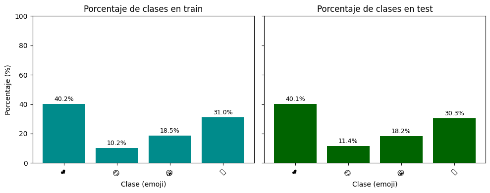

```python
# Porcentajes por clase en train y test
train_perc = df_train[LABEL_COL].value_counts(normalize=True).sort_index() * 100
test_perc  = df_test[LABEL_COL].value_counts(normalize=True).sort_index() * 100
fig, axes = plt.subplots(1, 2, figsize=(10, 4), sharey=True)
datasets = [("Porcentaje de clases en train", train_perc, axes[0], "#008B8B"),
    ("Porcentaje de clases en test",  test_perc,  axes[1], "#006400"),]
for title, perc, ax, color in datasets:
    bars = ax.bar(perc.index.astype(str), perc.values, color=color)
    ax.set_title(title)
    ax.set_xlabel("Clase (emoji)")
    ax.set_ylim(0, 100)
    ax.tick_params(axis='x', rotation=45)
    for bar in bars:
        h = bar.get_height()
        ax.text(bar.get_x() + bar.get_width()/2,
                h + 1,
                f"{h:.1f}%",
                ha="center", va="bottom", fontsize=9)
axes[0].set_ylabel("Porcentaje (%)")
plt.tight_layout()
plt.show()
```

# División de los datos en entrenamiento, validación y prueba

A continuación se realiza la separación de los datos en tres subconjuntos: entrenamiento, validación y prueba. Primero se extraen las columnas de interés del dataframe `df_train`. La variable `X` contiene únicamente el texto de los tweets (columna `text`), convertido explícitamente a tipo cadena con `astype(str)` para evitar problemas posteriores en el preprocesamiento. La variable `y` contiene la etiqueta de emoción (`klass`) asociada a cada tweet.

Posteriormente, se aplica la función `train_test_split` para dividir el conjunto original de entrenamiento en dos partes: un nuevo conjunto de entrenamiento (`X_train`, `y_train`) y un conjunto de validación (`X_val`, `y_val`). Se utiliza `test_size=0.2` para reservar el 20 % de los datos como validación, `stratify=y` para mantener la proporción de clases en ambos subconjuntos y `random_state=61` para que la partición sea reproducible. El conjunto de prueba (`X_test`, `y_test`) se toma directamente de `df_test`, utilizando las mismas columnas de texto y etiqueta.

```python
X = df_train[TEXT_COL].astype(str)
y = df_train[LABEL_COL]
X_train, X_val, y_train, y_val = train_test_split(
    X, y,
    test_size=0.2,
    stratify=y,
    random_state=61)
X_test = df_test[TEXT_COL].astype(str)
y_test = df_test[LABEL_COL]
print("Tamaño X_train:", X_train.shape[0])
print("Tamaño X_val  :", X_val.shape[0])
print("Tamaño X_test :", X_test.shape[0])
```

```
Tamaño X_train: 9419
Tamaño X_val  : 2355
Tamaño X_test : 2283
```

# Preprocesamiento del texto

Antes de vectorizar los tweets se define la función `simple_preprocess`, que aplica una limpieza básica al texto usando expresiones regulares. En concreto, convierte todo el contenido a minúsculas, reemplaza cualquier URL por el token `URL` y sustituye las menciones a usuarios (`@usuario`) por `USER` y los hashtags (`#tema`) por `HASHTAG`. Con estos pasos se normaliza el texto y se reducen variaciones innecesarias antes de construir las representaciones numéricas (por ejemplo, con TF-IDF) y entrenar los modelos de clasificación.

```python
def simple_preprocess(text):
    text = text.lower()
    text = re.sub(r'http\S+|www\.\S+', ' URL ', text)
    text = re.sub(r'@\w+', ' USER ', text)
    text = re.sub(r'#\w+', ' HASHTAG ', text)
    return text
```

# Vectorización del texto (BoW y TF-IDF)

Para convertir los tweets en representaciones numéricas se utilizan dos tipos de vectorizadores de `sklearn`: `CountVectorizer` y `TfidfVectorizer`. El primero genera una representación de bolsa de palabras, donde cada documento se describe por el conteo de aparición de cada término. El segundo calcula pesos TF-IDF, que consideran tanto la frecuencia del término en el documento como su rareza en el conjunto de datos. En ambos casos se usa la función `simple_preprocess` como preprocesador, se consideran uni-gramas y bi-gramas (`ngram_range=(1, 2)`) y se limita el vocabulario a las 20 000 características más frecuentes (`max_features=20000`) para reducir la dimensionalidad y el costo computacional.

```python
bow_vect = CountVectorizer(preprocessor=simple_preprocess, ngram_range=(1, 2), max_features=20000)
tfidf_vect = TfidfVectorizer(preprocessor=simple_preprocess, ngram_range=(1, 2), max_features=20000)
```

# Modelos de clasificación a comparar

Para organizar los modelos de clasificación se define un diccionario llamado `experiments` que contiene tres configuraciones diferentes, cada una implementada como un `Pipeline` de `sklearn`. En `"BoW + MultinomialNB"` se combina la representación de bolsa de palabras con el modelo Naive Bayes multinomial, un clasificador clásico para texto. En `"TFIDF + LinearSVC"` se utiliza la representación TF-IDF con una máquina de vectores de soporte lineal (`LinearSVC`), adecuada para datos de alta dimensión. Finalmente, `"TFIDF + SVC_RBF"` mantiene TF-IDF, pero emplea una SVM con kernel RBF (`SVC(C=1000, kernel='rbf')`).

```python
experiments = {
    "BoW + MultinomialNB": Pipeline([
        ('vect', bow_vect),
        ('clf', MultinomialNB())
    ]),
    "TFIDF + LinearSVC": Pipeline([
        ('vect', tfidf_vect),
        ('clf', LinearSVC())
    ]),
    "TFIDF + SVC_RBF": Pipeline([
        ('vect', tfidf_vect),
        ('clf', SVC(C=1000, kernel='rbf'))
    ]),}
```

# Evaluación de los modelos

La función `evaluate_model` se encarga de entrenar un modelo y calcular sus métricas de desempeño tanto en el conjunto de entrenamiento como en el de validación. Primero ajusta el clasificador con los datos de entrenamiento y genera las predicciones correspondientes. Después, mediante la función interna `compute_metrics`, calcula accuracy, precisión, recall y F1 con promedio macro y micro utilizando las funciones de `sklearn.metrics`. Las métricas se almacenan en dos diccionarios (`metrics_train` y `metrics_val`) y opcionalmente se imprimen en pantalla si `verbose=True`. Al final, la función devuelve el modelo ya entrenado y los diccionarios de métricas, lo que permite comparar de forma sistemática las distintas configuraciones.

```python
def evaluate_model(name, model, X_train, y_train, X_val, y_val, verbose=True):
    if verbose:
        print("="*80)
        print(f"Modelo: {name}")
    model.fit(X_train, y_train)
    y_tr_pred  = model.predict(X_train)
    y_val_pred = model.predict(X_val)
    def compute_metrics(y_true, y_pred):
        return {
            "Accuracy":        accuracy_score(y_true, y_pred),
            "Precision macro": precision_score(y_true, y_pred, average="macro"),
            "Recall macro":    recall_score(y_true, y_pred, average="macro"),
            "F1 macro":        f1_score(y_true, y_pred, average="macro"),
            "Precision micro": precision_score(y_true, y_pred, average="micro"),
            "Recall micro":    recall_score(y_true, y_pred, average="micro"),
            "F1 micro":        f1_score(y_true, y_pred, average="micro"),}
    metrics_train = compute_metrics(y_train, y_tr_pred)
    metrics_val   = compute_metrics(y_val,   y_val_pred)
    if verbose:
        for split_name, m in [("TRAIN", metrics_train), ("VAL", metrics_val)]:
            print(f"\n[{split_name}]")
            for k, v in m.items():
                print(f"{k:15s}: {v:.3f}")
    return model, metrics_train, metrics_val
```

# Comparación de modelos y selección del mejor

Las tablas de métricas de entrenamiento muestran que los tres modelos logran un buen ajuste sobre los datos de `X_train`, con valores elevados de accuracy y F1. Sin embargo, en las métricas de validación se observa una caída importante, en particular en las configuraciones basadas en SVM, lo que indica cierto sobreajuste. Al comparar los resultados en validación, el modelo **TFIDF + SVC_RBF** obtiene la mejor combinación de accuracy y F1 macro: alcanza una accuracy de alrededor de 0.55 y un F1 macro cercano a 0.46, ligeramente superiores a los valores obtenidos por `"BoW + MultinomialNB"` y `"TFIDF + LinearSVC"`.

Dado que la base de datos presenta clases desbalanceadas, se prioriza el F1 macro como criterio principal, ya que evalúa el desempeño promedio por clase sin favorecer a la clase mayoritaria. Con base en esta comparación, se selecciona explícitamente la configuración **TFIDF + SVC_RBF** como modelo final para la evaluación en el conjunto de prueba.

```python
results = {}
metrics_train_dict = {}
metrics_val_dict   = {}

for name, pipe in experiments.items():
    model, m_train, m_val = evaluate_model(
        name, pipe,
        X_train, y_train,
        X_val, y_val,
        verbose=False   # no imprimir cada vez
    )
    results[name] = {"model": model}
    metrics_train_dict[name] = m_train
    metrics_val_dict[name]   = m_val

df_train_metrics = pd.DataFrame(metrics_train_dict)
df_val_metrics   = pd.DataFrame(metrics_val_dict)

print("Métricas en ENTRENAMIENTO (filas = métricas, columnas = modelos):")
display(df_train_metrics)

print("\nMétricas en VALIDACIÓN (filas = métricas, columnas = modelos):")
display(df_val_metrics)
```

```
Métricas en ENTRENAMIENTO (filas = métricas, columnas = modelos):
```

|  | BoW + MultinomialNB | TFIDF + LinearSVC | TFIDF + SVC_RBF |
| --- | --- | --- | --- |
| Accuracy | 0.792441 | 0.981633 | 0.999363 |
| Precision macro | 0.814345 | 0.986665 | 0.999410 |
| Recall macro | 0.743513 | 0.971473 | 0.998847 |
| F1 macro | 0.766936 | 0.978715 | 0.999128 |
| Precision micro | 0.792441 | 0.981633 | 0.999363 |
| Recall micro | 0.792441 | 0.981633 | 0.999363 |
| F1 micro | 0.792441 | 0.981633 | 0.999363 |

```
Métricas en VALIDACIÓN (filas = métricas, columnas = modelos):
```

|  | BoW + MultinomialNB | TFIDF + LinearSVC | TFIDF + SVC_RBF |
| --- | --- | --- | --- |
| Accuracy | 0.538004 | 0.530361 | 0.553291 |
| Precision macro | 0.533629 | 0.492521 | 0.548422 |
| Recall macro | 0.431132 | 0.443801 | 0.445192 |
| F1 macro | 0.437565 | 0.454967 | 0.456141 |
| Precision micro | 0.538004 | 0.530361 | 0.553291 |
| Recall micro | 0.538004 | 0.530361 | 0.553291 |
| F1 micro | 0.538004 | 0.530361 | 0.553291 |

# Reentrenar el mejor modelo con TODO el train

Una vez comparadas las métricas de validación, se selecciona la configuración `TFIDF + SVC_RBF` como mejor modelo. En el código, se recupera este clasificador desde el diccionario `results` y se reentrena utilizando todo el conjunto original de entrenamiento (`X_full`, `y_full`), de manera que el modelo final aprovecha el máximo número de ejemplos antes de ser evaluado en el conjunto de prueba.

```python
best_name = "TFIDF + SVC_RBF"
best_model = results[best_name]["model"]

print("Modelo seleccionado como mejor:", best_name)

X_full = df_train[TEXT_COL].astype(str)
y_full = df_train[LABEL_COL]

best_model.fit(X_full, y_full)
```

```
Modelo seleccionado como mejor: TFIDF + SVC_RBF
```

```
Pipeline(steps=[('vect',
                 TfidfVectorizer(max_features=20000, ngram_range=(1, 2),
                                 preprocessor=<function simple_preprocess at 0x7e13ee0f7060>)),
                ('clf', SVC(C=1000))])
```

# Resultados del modelo en el conjunto de prueba

En el conjunto de prueba, el modelo TFIDF + SVC_RBF alcanza una accuracy de aproximadamente 0.5221. Las métricas de precisión, recall y F1 con promedio micro también toman este valor (≈ 0.5221), ya que en un problema multiclase la agregación micro coincide con la proporción global de aciertos. En cambio, las métricas macro son menores: la precisión macro es ≈ 0.5017, el recall macro ≈ 0.4174 y el F1 macro ≈ 0.4208, lo que indica que, en promedio por clase, el desempeño es más bajo que el promedio ponderado por frecuencia y que el modelo no se comporta igual de bien en todas las emociones.

El `classification_report` detalla este comportamiento por clase. El corazón (❤) es la emoción mejor reconocida, con precisión cercana a 0.60, recall de alrededor de 0.73 y un F1 de 0.66 sobre 915 ejemplos. La cara con ojos tristes (🥺) también presenta un desempeño razonable, con precisión ≈ 0.45, recall ≈ 0.58 y F1 ≈ 0.51 en 692 instancias. En cambio, la cara sonriente (😊) y la cara llorando (😭) muestran resultados claramente más débiles: para 😊 el F1 es ≈ 0.28 y para 😭 ≈ 0.24, lo que refleja que el modelo tiene más dificultad para distinguir estas emociones y tiende a confundirlas con otras clases.

```python
y_test_pred = best_model.predict(X_test)

print("Evaluación en TEST")
print("Accuracy:", accuracy_score(y_test, y_test_pred))
print("Precision macro:", precision_score(y_test, y_test_pred, average="macro"))
print("Recall macro   :", recall_score(y_test, y_test_pred, average="macro"))
print("F1 macro       :", f1_score(y_test, y_test_pred, average="macro"))
print("Precision micro:", precision_score(y_test, y_test_pred, average="micro"))
print("Recall micro   :", recall_score(y_test, y_test_pred, average="micro"))
print("F1 micro       :", f1_score(y_test, y_test_pred, average="micro"))

print("\nReporte por clase:")
print(classification_report(y_test, y_test_pred))
```

```
Evaluación en TEST
Accuracy: 0.522120017520806
Precision macro: 0.5016653733916772
Recall macro   : 0.41735142656211444
F1 macro       : 0.4208202528536237
Precision micro: 0.522120017520806
Recall micro   : 0.522120017520806
F1 micro       : 0.522120017520806

Reporte por clase:
              precision    recall  f1-score   support

           ❤       0.60      0.73      0.66       915
           😊       0.59      0.18      0.28       261
           😭       0.37      0.18      0.24       415
           🥺       0.45      0.58      0.51       692

    accuracy                           0.52      2283
   macro avg       0.50      0.42      0.42      2283
weighted avg       0.51      0.52      0.49      2283
```

# Matriz de confusión del modelo TFIDF + SVC_RBF

La matriz de confusión muestra cómo se comporta el clasificador para cada una de las emociones en el conjunto de prueba. En la diagonal se observan los aciertos: de los 915 ejemplos verdaderos de la clase *corazón*, el modelo clasifica correctamente 672 (alrededor del 73 %); para la clase *cara con ojos tristes* acierta en 399 de 692 casos (≈ 58 %). En cambio, el desempeño es más bajo para la *cara sonriente* y la *cara llorando*: solo 47 de 261 ejemplos de *cara sonriente* (≈ 18 %) y 74 de 415 ejemplos de *cara llorando* (≈ 18 %) quedan bien clasificados. Esto confirma que el modelo reconoce mejor las clases *corazón* y *cara con ojos tristes* que las emociones relacionadas con sonrisa y llanto.

En conjunto, la matriz de confusión refuerza la idea de que el clasificador funciona mejor en las clases mayoritarias y más claras (*corazón* y *cara con ojos tristes*), mientras que presenta dificultades importantes para distinguir correctamente las clases *cara sonriente* y *cara llorando*.

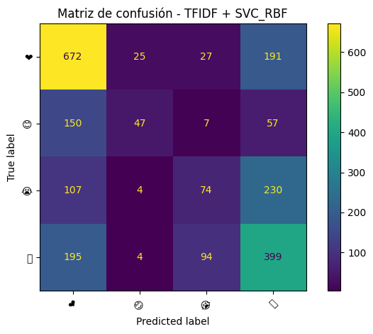

```python
labels = sorted(df_train[LABEL_COL].unique())

ConfusionMatrixDisplay.from_predictions(y_test, y_test_pred, display_labels=labels)
plt.title(f"Matriz de confusión - {best_name}")
plt.xticks(rotation=45)
plt.tight_layout()
plt.show()
```

# Conclusiones

En este trabajo se implementó un flujo completo de clasificación de texto para predecir la emoción asociada a tweets a partir de cuatro clases (corazón, cara sonriente, cara llorando y cara con ojos tristes). Se cargaron y limpiaron los datos, se aplicó un preprocesamiento básico del texto y se probaron distintas combinaciones de vectorización (BoW y TF-IDF) y modelos de clasificación (Naive Bayes multinomial y SVM lineal y con kernel RBF).

Durante el preprocesamiento se comparó el desempeño del modelo con y sin eliminación de stopwords. Para no hacer el documento más extenso, en esta práctica se decidió documentar solo el flujo con stopwords, ya que el F1 macro en validación fue ligeramente mejor cuando se conservaron todas las palabras. Además, muchas de estas stopwords (como “no”, “nunca” o “nada”) son relevantes para expresar polaridad y matices emocionales, por lo que se optó por trabajar con el texto completo en los vectorizadores.

Las métricas de entrenamiento y validación mostraron cierto sobreajuste, especialmente en los modelos SVM, pero el modelo TFIDF + SVC_RBF obtuvo la mejor combinación de accuracy y F1 macro y se eligió como modelo final. En el conjunto de prueba alcanzó una accuracy cercana a 0.52 y un F1 macro aproximado de 0.42, lo que indica un desempeño moderado: acierta en algo más de la mitad de los tweets, aunque no clasifica todas las emociones con la misma calidad.

El análisis del `classification_report` y de la matriz de confusión mostró que las clases corazón y cara con ojos tristes son las mejor reconocidas, mientras que la cara sonriente y la cara llorando presentan F1 y recall más bajos y se confunden con mayor frecuencia.

**Documento en Colab** [enlace](https://colab.research.google.com/drive/1gzckLoptU66cZdG580WM83GLZZNZuGhK?usp=sharing).

# Referencias

Ruiz Velázquez, L. G. (2025). *Clasificación y medición del desempeño* [PDF]. INFOTEC – Centro de Investigación e Innovación en Tecnologías de la Información y Comunicación.

Ruiz Velázquez, L. G. (2025). *Ejemplo clasificador.ipynb* [Colab]. INFOTEC – Centro de Investigación e Innovación en Tecnologías de la Información y Comunicación.

Ruiz Velázquez, L. G. (2025). *Clasificación* [Video]. INFOTEC – Centro de Investigación e Innovación en Tecnologías de la Información y Comunicación.

scikit-learn developers. (s. f.). *sklearn.metrics: Metric functions* [Documentación]. scikit-learn. Recuperado el 20 de noviembre de 2025 de https://scikit-learn.org/stable/modules/classes.html#module-sklearn.metrics